# Fiche 4 - Exercice 1

## Question 3

### Estimation du biais des estimateurs.

On simule $m$ échantillons de taille $n$ de la loi $\exp(\lambda)$. Pour chaque échantillon, on calcule la valeur de l’EMV $\hat{\lambda}_n$. On obtient donc un échantillon de taille $m$ de la loi de $\hat{\lambda}_n$.

L’histogramme de cet échantillon donne une estimation de la densité de la loi de $\hat{\lambda}_n$.

La moyenne empirique des valeurs obtenues est une estimation de l’espérance de cette loi. Si onlève $\lambda$ à cette moyenne, on obtient donc une estimation du biais de l’estimateur $E\left[\hat{\lambda}_n\right] - \lambda$.

On fait la même chose avec l’ESBVM $\hat{\lambda}'_n$.

```r
BiaisExp<-function(m,n,lambda)
{
EMV<-rep(0,m)
ESBVM<-rep(0,m)
sim <- replicate(m,rexp(n,lambda))
EMV<-n/colSums(sim)
ESBVM<-(n-1)/colSums(sim)
par(mfcol=c(1,2))
hist(EMV,prob=T)
lines(c(lambda,lambda),c(0,10),col="blue",lwd=4)
lines(c(mean(EMV),mean(EMV)),c(0,10),col="red",lwd=4)
hist(ESBVM,prob=T)
lines(c(lambda,lambda),c(0,10),col="blue",lwd=4)
lines(c(mean(ESBVM),mean(ESBVM)),c(0,10),col="green",lwd=4)
cat("Moyenne des biais de l’EMV", mean(EMV-lambda),"\n")
cat("Moyenne des biais de l’ESBVM", mean(ESBVM-lambda),"\n")
}
```

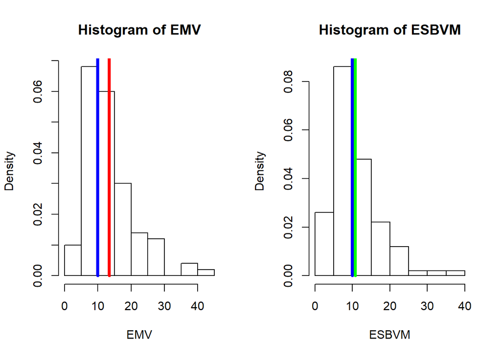

```
## Moyenne des biais de l’EMV 3.383615
## Moyenne des biais de l’ESBVM 0.7068924
```

```r
BiaisExp(100,5,10)
```

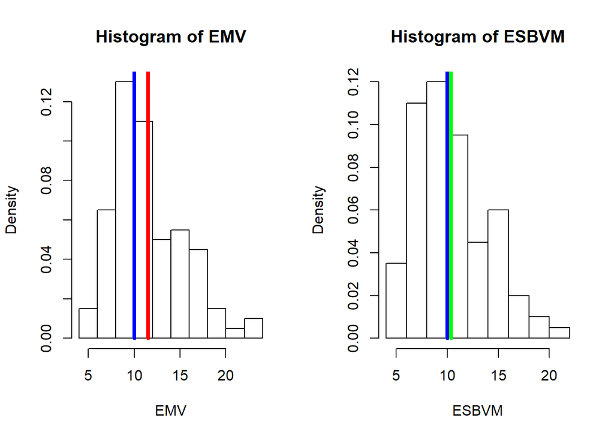

```
## Moyenne des biais de l’EMV 1.501332
## Moyenne des biais de l’ESBVM 0.3511989
```

```r
BiaisExp(100,10,10)
```

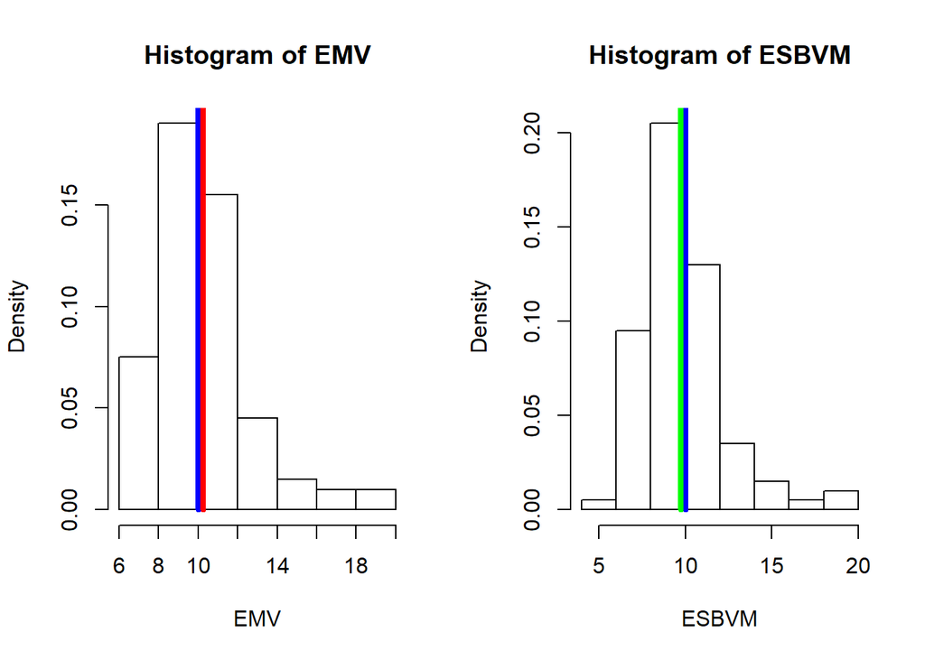

```
## Moyenne des biais de l’EMV 0.2563319
## Moyenne des biais de l’ESBVM -0.2564846
```

```r
BiaisExp(100,20,10)
```

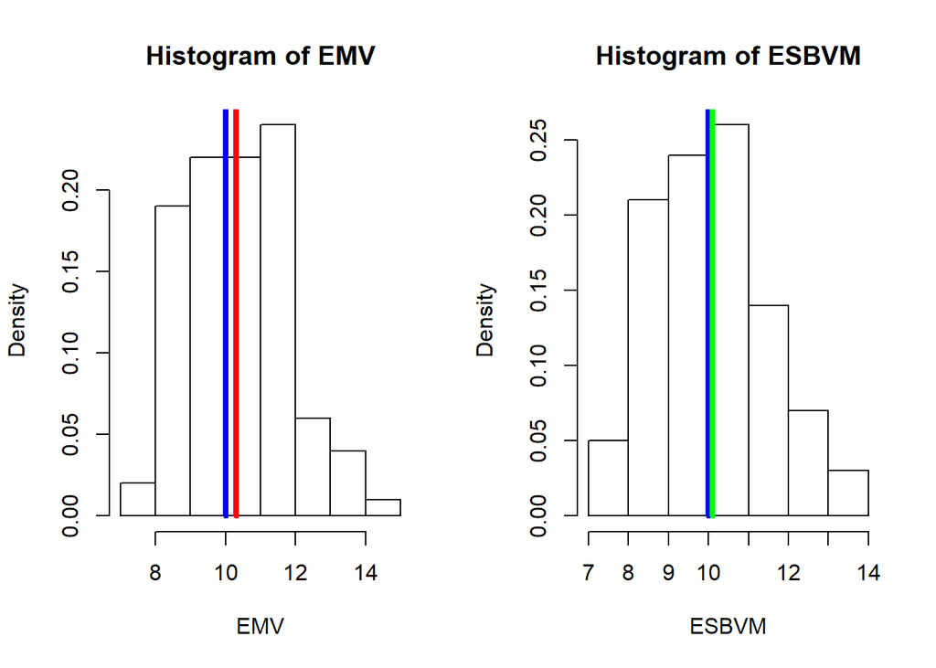

```
## Moyenne des biais de l’EMV 0.3070145
## Moyenne des biais de l’ESBVM 0.1008742
```

```r
BiaisExp(100,50,10)
```

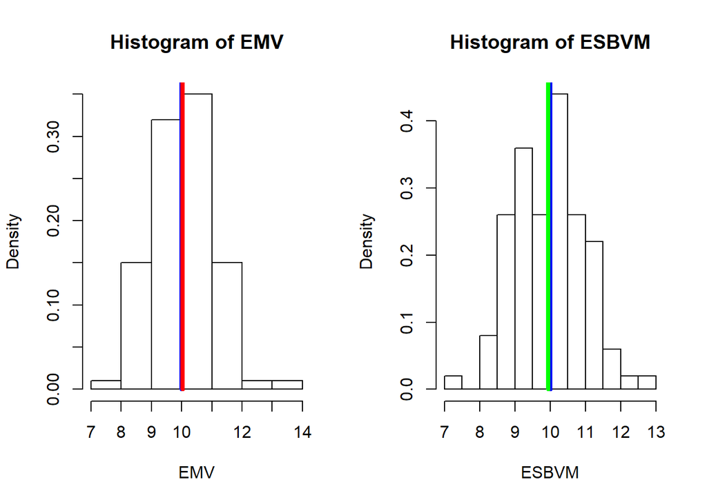

```
## Moyenne des biais de l’EMV 0.03826555
## Moyenne des biais de l’ESBVM -0.06211711
```

```r
BiaisExp(100,100,10)
```

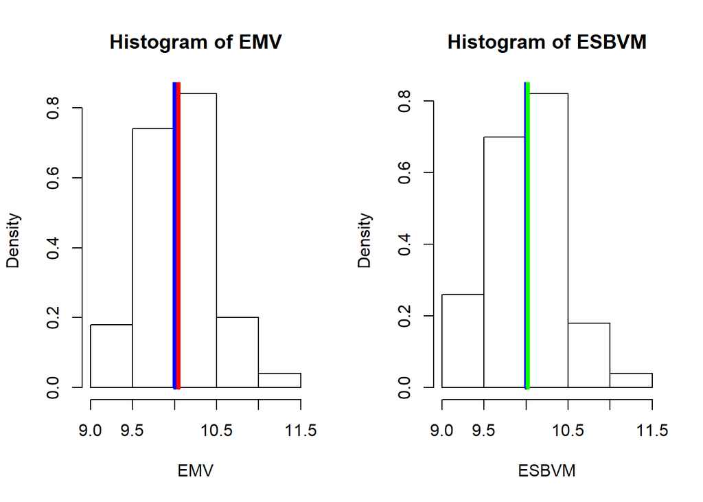

```
## Moyenne des biais de l’EMV 0.04242294
## Moyenne des biais de l’ESBVM 0.0223381
```

```r
BiaisExp(100,500,10)
```

Sur les histogrammes, la vraie valeur de $\lambda$ est en bleu, l’espérance estimée de l’EMV est en rouge et l’espérance estimée de l’ESBVM est en vert. On constate que :

- L’EMV sur-estime $\lambda$. Ce n’est pas le cas de l’ESBVM. C’est flagrant pour $n$ petit, de moins en moins quand $n$ grandit. Cela illustre que l’EMV est biaisé et l’ESBVM est sans biais. Attention, bien que l’ESBVM soit sans biais, il ne faut pas s’attendre à ce que le biais estimé soit nul, il doit simplement être proche de zéro (ce qui est le cas).
- Le biais de l’EMV diminue quand $n$ grandit. Cela illustre que l’EMV est asymptotiquement sans biais.
- Pour $n$ petit, les histogrammes des estimateurs ne sont pas du tout en forme de cloche symétrique. Quand $n$ grandit, leur forme se rapproche d’une cloche symétrique. Cela illustre que les 2 estimateurs sont asymptotiquement de loi normale (propriété 4 du poly).

### Estimation de l’erreur quadratique moyenne des estimateurs

```r
EQMExp<-function(m,n,lambda)
{
EMV<-rep(0,m)
ESBVM<-rep(0,m)
sim <- replicate(m,rexp(n,lambda))
EMV<-n/colSums(sim)
ESBVM<-(n-1)/colSums(sim)
cat("Moyenne des EQM de l’EMV", mean((EMV-lambda)^2),"\n")
cat("Moyenne des EQM de l’ESBVM", mean((ESBVM-lambda)^2),"\n")
}
```

```r
EQMExp(100,5,10)
```

```
## Moyenne des EQM de l’EMV 38.87755
## Moyenne des EQM de l’ESBVM 21.23247
```

```r
EQMExp(100,10,10)
```

```
## Moyenne des EQM de l’EMV 14.74393
## Moyenne des EQM de l’ESBVM 10.62991
```

```r
EQMExp(100,20,10)
```

```
## Moyenne des EQM de l’EMV 9.06454
## Moyenne des EQM de l’ESBVM 7.671128
```

```r
EQMExp(100,50,10)
```

```
## Moyenne des EQM de l’EMV 1.164552
## Moyenne des EQM de l’ESBVM 1.216968
```

```r
EQMExp(100,100,10)
```

```
## Moyenne des EQM de l’EMV 1.45063
## Moyenne des EQM de l’ESBVM 1.364657
```

```r
EQMExp(100,500,10)
```

```
## Moyenne des EQM de l’EMV 0.2301895
## Moyenne des EQM de l’ESBVM 0.2290325
```

On constate que :

- Pour les 2 estimateurs, l’EQM tend vers 0 quand $n$ grandit. Cela illustre que les 2 estimateurs sont convergents en moyenne quadratique.
- Pour $n$ petit, l’EQM de l’EMV est bien plus grande que celle de l’ESBVM, à cause du biais. La différence s’estompe quand $n$ grandit.